# Distribuições contínuas

ProbEst

fnaufel

Criado em 13/11/2020 Versão de 17/09/2021

# 1 Uniforme

## 1.1 Exemplo: gerador de números aleatórios

- Um programa para gerar números aleatórios no intervalo $[0, 10]$.
- A probabilidade é distribuída *uniformemente* neste intervalo.
- A variável aleatória $X$ representa os números gerados.

### $P(X = x) = 0!$

Como $X$ é uma variável aleatória contínua, as probabilidades $P(X = 1)$, $P(X = 3{,}1416)$, ou qualquer outra probabilidade pontual $P(X = x)$ é igual a zero!

- A fdp (função de densidade de probabilidade) de $X$ é
  $$f(x) =
  \begin{cases}
  \frac{1}{10} & \text{se } x \in [0, 10] \\
  0 & \text{se } x \not\in [0, 10]
  \end{cases}$$
  cujo gráfico é

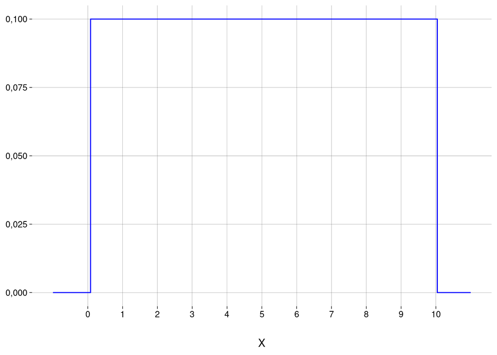

### Densidade não é probabilidade!

Perceba que a *probabilidade* $P(X = 5)$ é $0$, mas a *densidade* $f(5)$ é $1/10$.

- A probabilidade de um número gerado estar entre $5$ e $7$ é de
  $$P(5 < X < 7) = P(5 \leq X \leq 7) = \int_5^7 f(x)dx = \int_5^7 \frac{1}{10}dx = \frac{1}{5}$$
- O valor esperado de $X$ é
  $$E(X) = \int_{-\infty}^{\infty} xf(x)dx = \int_{0}^{10} \frac{1}{10}xdx = 5$$
- A variância de $X$ é
  $$\sigma^2(X)
  = \int_{-\infty}^{+ \infty} (x - 5)^2 \cdot f(x) dx
  = \int_{0}^{10} (x-5)^2 \cdot \frac{1}{10} dx
  = \frac{25}{3}
  = 8{,}33$$
- **Exercício:** calcule $\sigma^2(X)$ usando a fórmula $\sigma^2(X) = E(X^2) - [E(X)]^2$.

## 1.3 Em R

### 1.3.1 Função de densidade de probabilidade: $f(x \mid a, b)$

- `dunif(x, min = 0, max = 1)`
- No exemplo do gerador de números aleatórios em $[0, 10]$, todos os valores no intervalo têm a mesma densidade: $\frac{1}{10}$. Valores fora do intervalo têm densidade $0$:

```r
dunif(
  c(-1, 1, 2, 10, 11),
  min = 0,
  max = 10
)
```

```
## [1] 0,0 0,1 0,1 0,1 0,0
```

### 1.3.2 Função de probabilidade acumulada: $\text{Unif}(X \leq q \mid a, b)$

- `punif(q, min = 0, max = 1, lower.tail = TRUE)`
- No exemplo do gerador de números aleatórios no intervalo $[0, 10]$, qual a probabilidade de obter um número menor que $4$?

```r
punif(4, min = 0, max = 10)
```

```
## [1] 0,4
```

- E um número maior que $4$?

```r
punif(4, min = 0, max = 10, lower.tail = FALSE)
```

```
## [1] 0,6
```

### 1.3.3 Função quantil: dado um valor de $\text{Unif}(X \leq x \mid a, b)$, então $x = ?$

- `qunif(p, min = 0, max = 1, lower.tail = TRUE)`
- No exemplo do gerador de números aleatórios no intervalo $[0, 10]$, qual o número $x$ tal que existe uma probabilidade de $80\%$ de que um número menor ou igual a $x$ seja gerado?

```r
qunif(.8, min = 0, max = 10)
```

```
## [1] 8
```

- E qual o número $x$ tal que existe uma probabilidade de $80\%$ de que um número maior ou igual a $x$ seja gerado?

```r
qunif(.8, min = 0, max = 10, lower.tail = FALSE)
```

```
## [1] 2
```

### 1.3.4 Geração de números aleatórios

- `runif(n, min = 0, max = 1)`
- Os números gerados são de ponto flutuante:

```r
runif(10, min = 0, max = 10)
```

```
##  [1] 0,83686164 6,73827413 4,49339387 7,81868301 8,94226127 1,06673256
##  [7] 5,50939406 0,09794698 2,11825073 7,90134696
```

- **Exercício:** e se você quiser gerar apenas números inteiros no intervalo dado?
- **Exercício:** os números `min` e `max` podem ser gerados?

# 2 Normal

## 2.1 Exemplo

- Segundo o [Levantamento do Perfil Antropométrico da População Brasileira Usuária do Transporte Aéreo Nacional](https://www2.anac.gov.br/arquivos/pdf/Relatorio_Final_Projeto_Conhecer.pdf), em 2009, a estatura do homem brasileiro adulto era distribuída normalmente, com média $1{,}73$m e desvio padrão $0{,}07$m.
- Segundo [este livro](https://www.pearson.com/us/higher-education/product/De-Veaux-Stats-Data-and-Models-Plus-NEW-My-Lab-Statistics-with-Pearson-e-Text-Access-Card-Package-4th-Edition/9780133956498.html), a estatura do homem holandês é distribuída normalmente, com média $1{,}84$m e desvio padrão $0{,}08$m.

```r
mu_brasil <- 1.73
sigma_brasil <- .07

mu_holanda <- 1.84
sigma_holanda <- .08
```

- Gráfico:

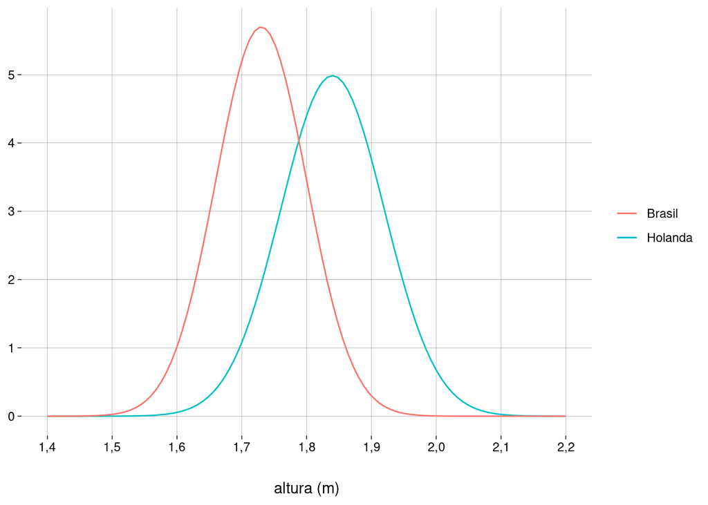

## 2.2 No geral

- $X \sim \mathcal{N}(\mu, \sigma)$
- Média: $\mu \in \mathbb{R}$
- Desvio padrão: $\sigma \in \mathbb{R}_{\geq 0}$
- Suporte: $(-\infty, \infty)$
- Fdp:
  $$f(x \mid \mu, \sigma) =
  \frac{1}{\sigma \sqrt{2\pi}}
  e^{-\frac{1}{2}\left(\frac{x - \mu}{\sigma}\right)^2}$$

## 2.3 Em R

### 2.3.1 Função de densidade de probabilidade: $f(x \mid \mu, \sigma)$

- `dnorm(x, mean = 0, sd = 1)`

### 2.3.2 Função de probabilidade acumulada: $\text{Norm}(X \leq q \mid \mu, \sigma)$

- `pnorm(q, mean = 0, sd = 1, lower.tail = TRUE)`
- Qual a probabilidade de um homem brasileiro ter entre $1{,}80$m e $1{,}90$m de altura?
- Gráfico:

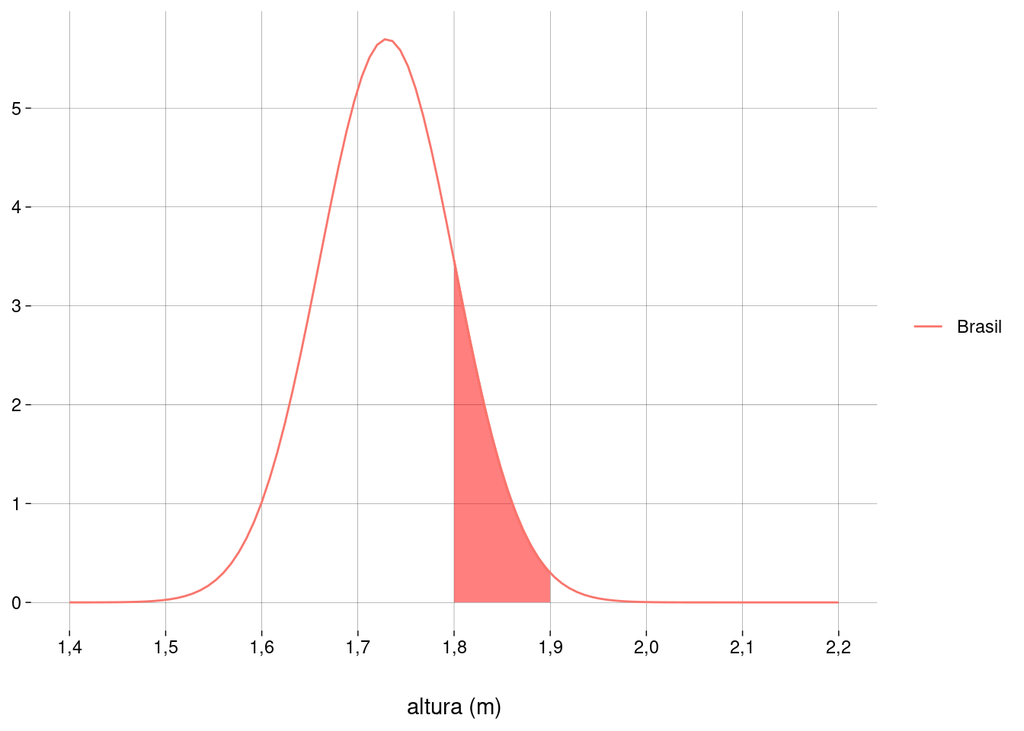

- Menos que $1{,}80$m:

```r
pnorm(1.80, mu_brasil, sigma_brasil)
```

```
## [1] 0,8413447
```

- Menos que $1{,}90$m:

```r
pnorm(1.90, mu_brasil, sigma_brasil)
```

```
## [1] 0,9924208
```

- Entre $1{,}80$m e $1{,}90$m:

```r
pnorm(1.90, mu_brasil, sigma_brasil) - pnorm(1.80, mu_brasil, sigma_brasil)
```

```
## [1] 0,151076
```

- Qual a probabilidade de um homem holandês ter entre $1{,}80$m e $1{,}90$m de altura?
- Gráfico:

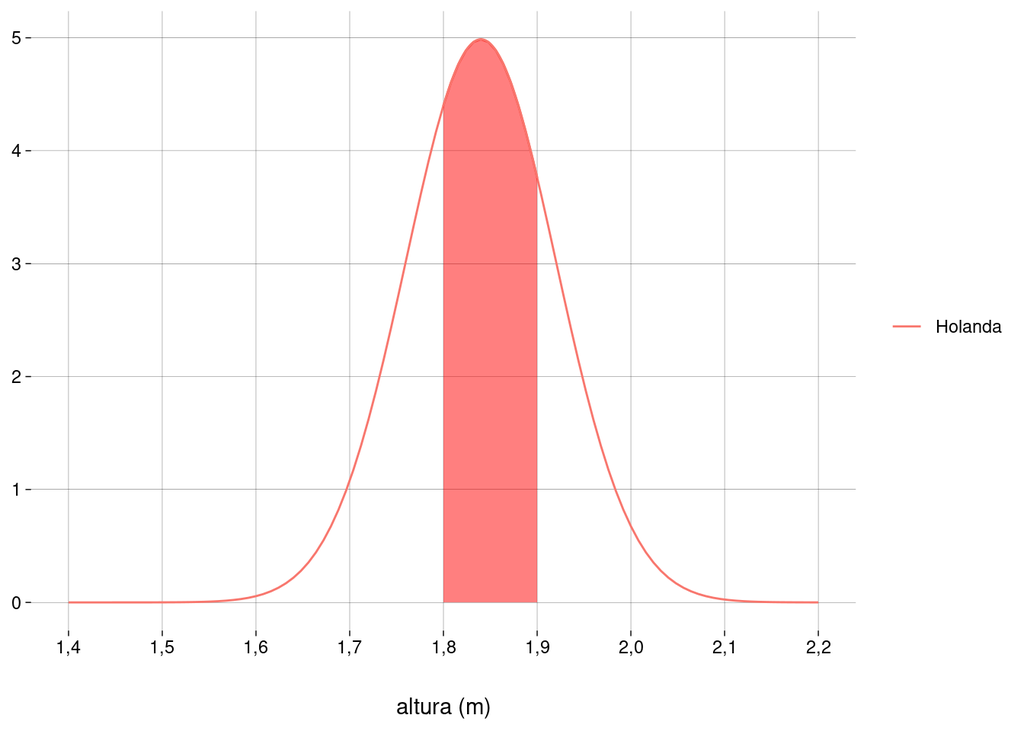

- Menos que $1{,}80$m:

```r
pnorm(1.80, mu_holanda, sigma_holanda)
```

```
## [1] 0,3085375
```

- Menos que $1{,}90$m:

```r
pnorm(1.90, mu_holanda, sigma_holanda)
```

```
## [1] 0,7733726
```

- Entre $1{,}80$m e $1{,}90$m:

```r
pnorm(1.90, mu_holanda, sigma_holanda) - pnorm(1.80, mu_holanda, sigma_holanda)
```

```
## [1] 0,4648351
```

### 2.3.3 Função quantil: dado um valor de $\text{Norm}(X \leq x \mid \mu, \sigma)$, então $x = ?$

- `qnorm(p, mean = 0, sd = 1, lower.tail = TRUE)`
- Quais as alturas mínima e máxima dos homens que estão nos $50\%$ da população em torno da média?
- Gráfico:

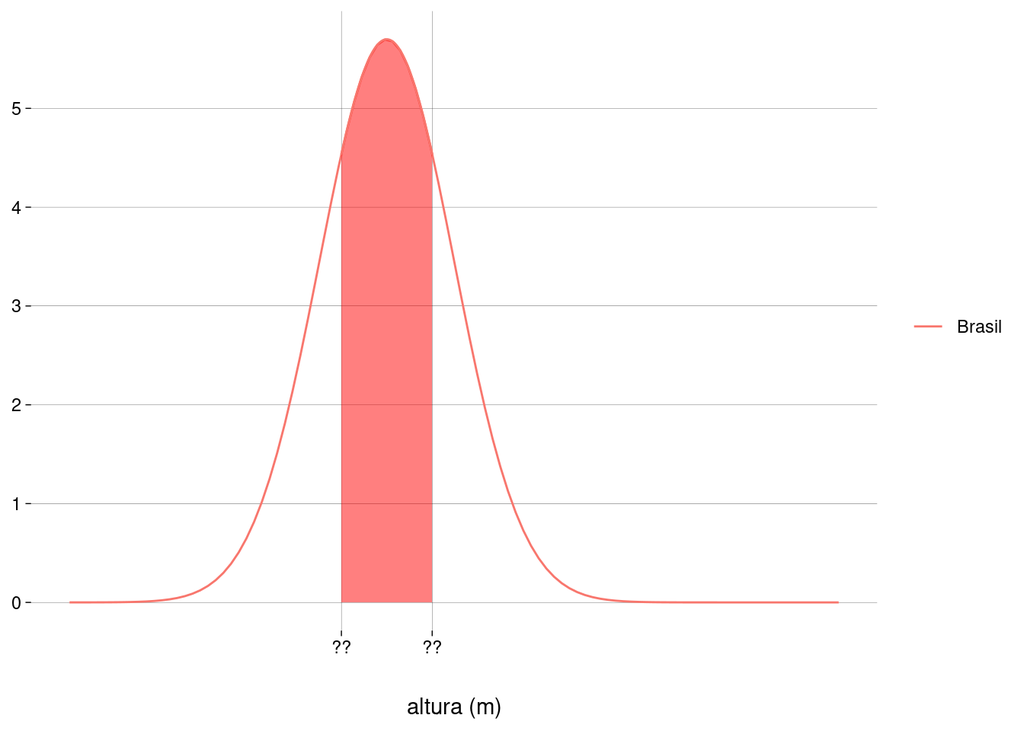

- O limite inferior é o valor à esquerda do qual existem $25\%$ de probabilidade:

```r
qnorm(.25, mu_brasil, sigma_brasil)
```

```
## [1] 1,682786
```

- O limite superior é o valor à esquerda do qual existem $75\%$ de probabilidade:

```r
qnorm(.75, mu_brasil, sigma_brasil)
```

```
## [1] 1,777214
```

- Ou, equivalentemente, o valor à direita do qual existem $25\%$ de probabilidade:

```r
qnorm(.25, mu_brasil, sigma_brasil, lower.tail = FALSE)
```

```
## [1] 1,777214
```

- As alturas mínima e máxima dos homens que estão nos $50\%$ da população em torno da média são $1{,}68$m e $1{,}78$m.

### 2.3.4 Geração de números aleatórios

- `rnorm(n, mean = 0, sd = 1)`
- Qual é a probabilidade de um homem holandês escolhido ao acaso ser mais baixo do que um homem brasileiro escolhido ao acaso?
- Vamos responder fazendo uma simulação.
- Vamos repetir muitas vezes o experimento de escolher um holandês ao acaso e um brasileiro ao acaso:

```r
n <- 1e6
holandeses <- rnorm(n, mu_holanda, sigma_holanda)
brasileiros <- rnorm(n, mu_brasil, sigma_brasil)
```

- Qual a proporção de vezes em que o holandês é mais baixo?

```r
mean(holandeses < brasileiros)
```

```
## [1] 0,15133
```

- Segundo nossa simulação, esta é a probabilidade de um holandês ser mais baixo que um brasileiro.

## 2.4 QQplots

- Como saber se um conjunto de dados numéricos segue a distribuição normal?
- Vamos gerar dados aproximadamente normais (média $0$, desvio padrão $1$):

```r
valores <- rnorm(1000)
head(valores)
```

```
## [1]  0,7602279  0,1486861 -1,6718189 -1,1192180  0,3208325  1,0555033
```

- Histograma:

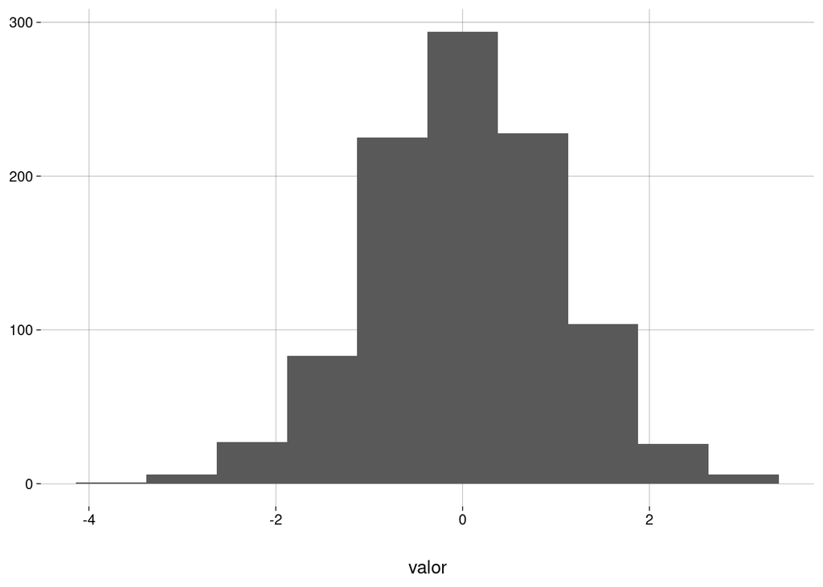

```r
valores %>%
  as_tibble() %>%
  ggplot() +
    geom_histogram(aes(x = value), bins = 10) +
    labs(
      x = 'valor',
      y = NULL
    )
```

- Para estes dados, os quartis são

```r
quantile(valores)
```

```
##           0%          25%          50%          75%         100%
## -3,630775231 -0,635069272  0,005660656  0,702500450  3,141297579
```

- Na distribuição $\mathcal{N}(0, 1)$ teórica, os quartis seriam

```r
qnorm(c(0, .25, .5, .75, 1))
```

```
## [1]       -Inf -0,6744898  0,0000000  0,6744898        Inf
```

- O gráfico QQ (quantil-quantil) mostra os quantis da amostra no eixo $y$ e os quantis teóricos no eixo $x$. A reta vermelha serve para referência; se as duas distribuições fossem idênticas, todos os pontos estariam sobre a reta.

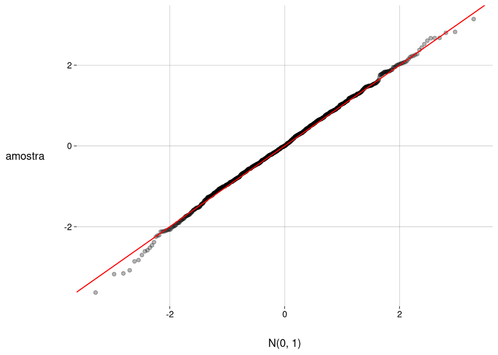

```r
valores %>%
  as_tibble() %>%
  ggplot(aes(sample = value)) +
    geom_qq(alpha = .3) +
    labs(
      y = 'amostra',
      x = 'N(0, 1)'
    ) +
    geom_abline(color = 'red')
```

- Um exemplo concreto: pesos de $15$ mulheres com idades entre $30$ e $39$ anos:

```r
pesos <- women %>%
  select(weight) %>%
  transmute(peso = weight * .4535924)
```

- Histograma:

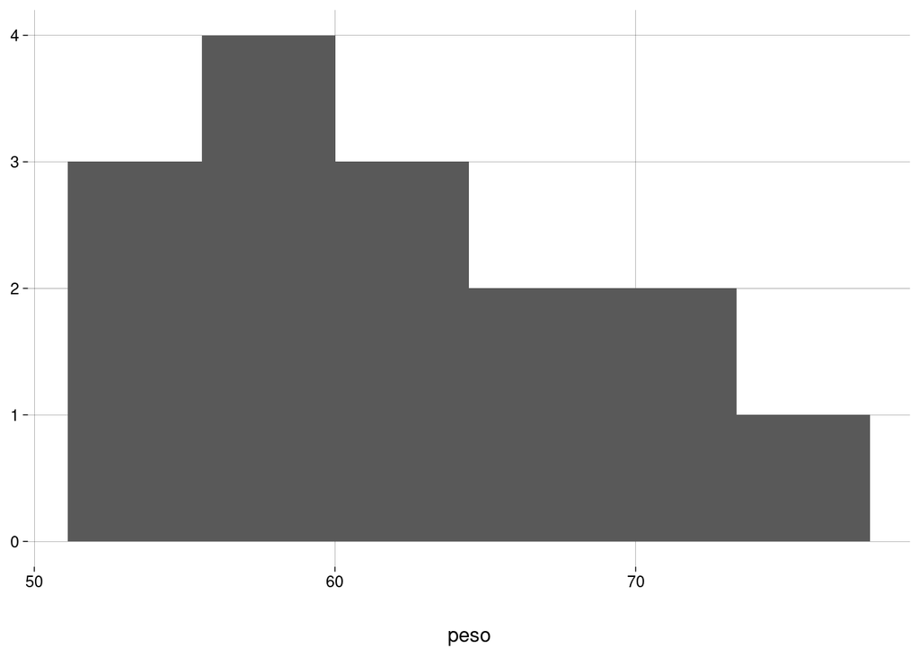

```r
pesos %>%
  ggplot() +
    geom_histogram(aes(x = peso), bins = 6) +
    labs(y = NULL)
```

- O gráfico quantil-quantil fica

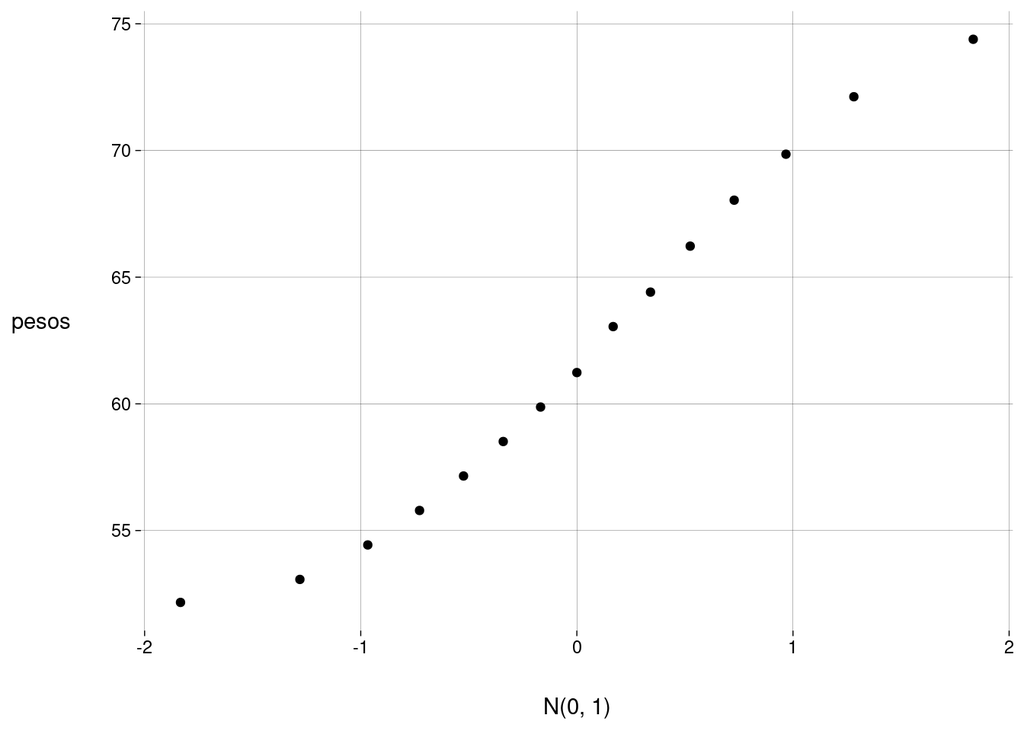

```r
pesos %>%
  ggplot(aes(sample = peso)) +
    geom_qq() +
    labs(
      y = 'pesos',
      x = 'N(0, 1)'
    )
```

- Quanto mais próximos de uma reta com inclinação de $45$ graus os pontos ficarem, mais próximos da distribuição normal os dados estão.
- Podemos usar, como distribuição teórica no eixo $x$, a distribuição normal com média e desvio padrão iguais à média e ao desvio padrão dos dados:

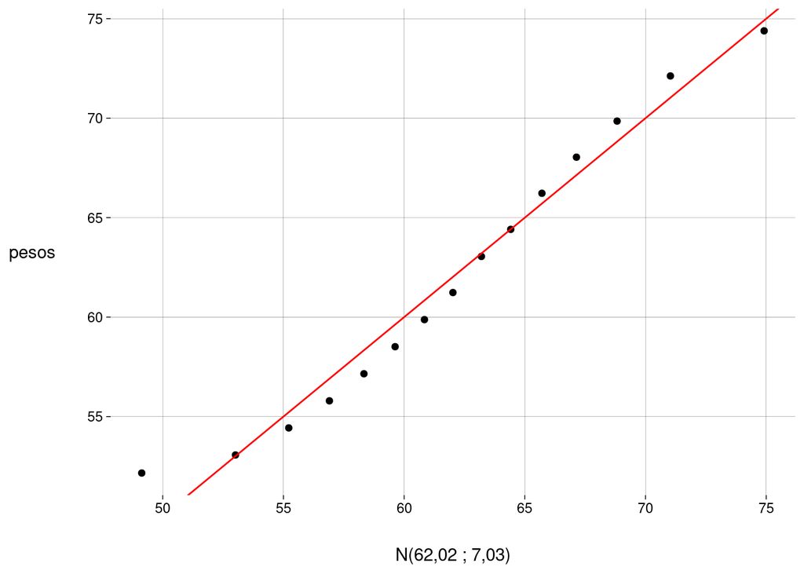

```r
m <- mean(pesos$peso)
s <- sd(pesos$peso)

pesos %>%
  ggplot(aes(sample = peso)) +
    geom_qq(
      dparams = list(
        mean = m,
        sd = s
      )
    ) +
    geom_abline(color = 'red') +
    labs(
      y = 'pesos',
      x = paste0('N(', m %>% round(2), ' ; ', s %>% round(2), ')')
    )
```

- Ou podemos padronizar os dados no eixo $y$, fazendo com que a média deles seja $0$ e o desvio padrão deles seja $1$.
- Para fazer isso manualmente, basta subtrair a média e dividir pelo desvio padrão:

```r
pesos %>%
  mutate(peso = (peso - mean(peso)) / sd(peso)) %>%
  kbl(
    format.args = list(big.mark = '.')
  ) %>%
  kable_paper(
    c('striped', 'hover'),
    full_width = FALSE
  )
```

| peso |
| --- |
| -1,4022687 |
| -1,2732255 |
| -1,0796608 |
| -0,8860962 |
| -0,6925315 |
| -0,4989668 |
| -0,3054021 |
| -0,1118374 |
| 0,1462489 |
| 0,3398136 |
| 0,5978998 |
| 0,8559861 |
| 1,1140723 |
| 1,4366802 |
| 1,7592880 |

- Ou podemos usar a função `scale`, que faz o mesmo:

```r
pesos %>%
  mutate(peso = scale(peso)) %>%
  kbl(
    format.args = list(big.mark = '.')
  ) %>%
  kable_paper(
    c('striped', 'hover'),
    full_width = FALSE
  )
```

| peso |
| --- |
| -1,4022687 |
| -1,2732255 |
| -1,0796608 |
| -0,8860962 |
| -0,6925315 |
| -0,4989668 |
| -0,3054021 |
| -0,1118374 |
| 0,1462489 |
| 0,3398136 |
| 0,5978998 |
| 0,8559861 |
| 1,1140723 |
| 1,4366802 |
| 1,7592880 |

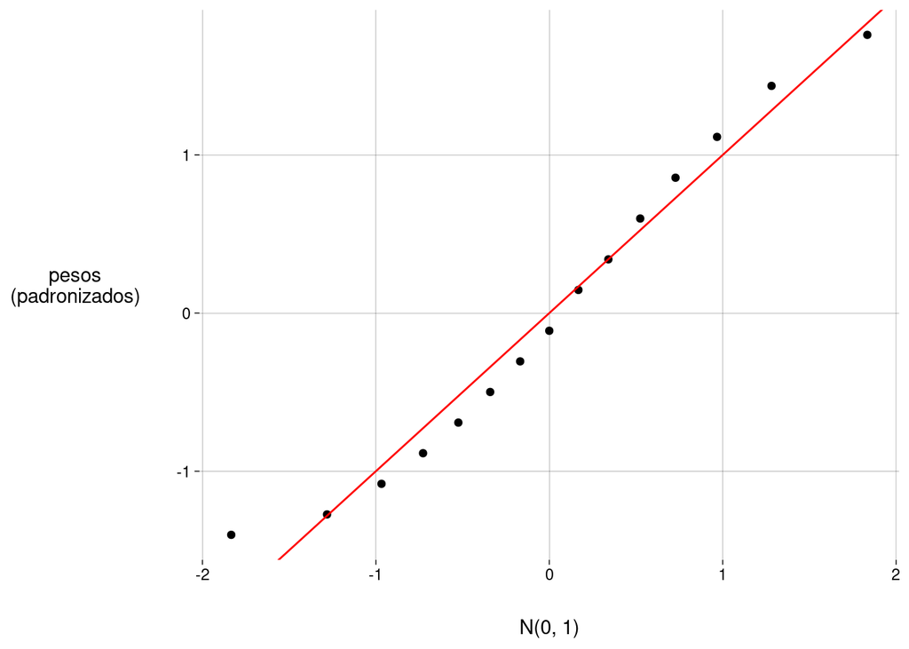

```r
pesos %>%
  mutate(peso = scale(peso)) %>%
  ggplot(aes(sample = peso)) +
    geom_qq() +
    labs(
      y = 'pesos\n(padronizados)',
      x = 'N(0, 1)'
    ) +
    geom_abline(color = 'red')
```

- Um exemplo de dados não normais:

```r
dados <- rexp(100, rate = .1)
m <- mean(dados)
s <- sd(dados)
```

- Histograma:

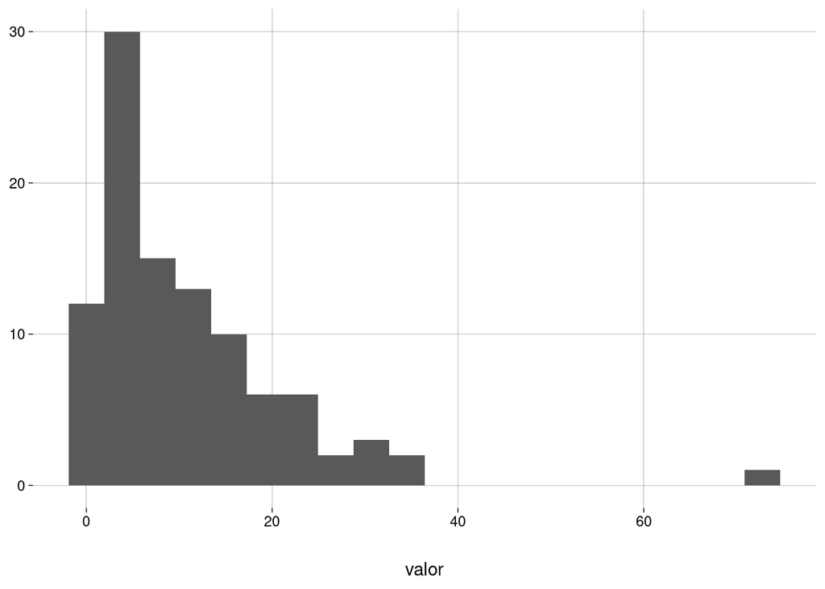

```r
dados %>%
  as_tibble() %>%
  ggplot() +
    geom_histogram(aes(x = value), bins = 20) +
    labs(
      x = 'valor',
      y = NULL
    )
```

- QQ:

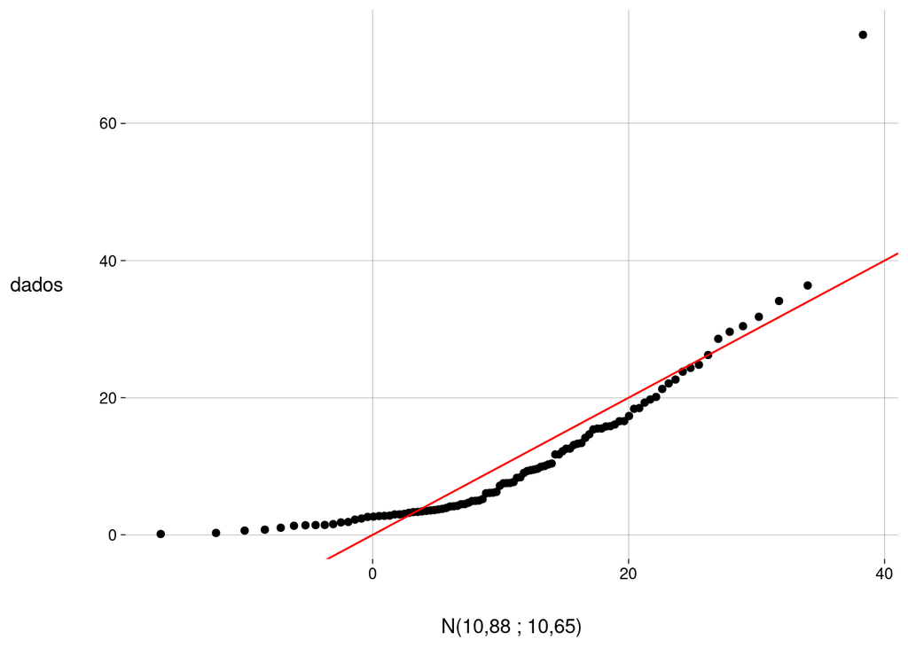

```r
dados %>%
  as_tibble() %>%
  ggplot(aes(sample = value)) +
    geom_qq(
      dparams = list(
        mean = m,
        sd = s
      )
    ) +
    geom_abline(color = 'red') +
    labs(
      y = 'dados',
      x = paste0('N(', m %>% round(2), ' ; ', s %>% round(2), ')')
    )
```

- **Exercício**: gere um gráfico quantil-quantil para estes dados, usando a distribuição exponencial com média $10$ como distribuição teórica no eixo $x$.

## 2.5 Aproximação da binomial pela normal

- Exemplo:
  - Uma organização vai receber sangue de $32$ mil doadores escolhidos ao acaso.
  - A probabilidade de um doador ter sangue tipo O- é $p = 0{,}06$.
  - Qual a probabilidade de a organização conseguir no mínimo $1.850$ doadores com sangue do tipo O-?
- Cada doador é uma prova de Bernoulli, com probabilidade de sucesso $p = 0{,}06$. Supondo que os doadores são independentes (por exemplo, não são todos parentes) e usando a distribuição binomial, a resposta é
  $$\text{Binom}(X \geq 1850 \mid n = 32000, p = 0.06)$$
- Em R

```r
pbinom(
  q = 1849,
  size = 32000,
  prob = 0.06,
  lower.tail = FALSE
)
```

```
## [1] 0,9521106
```

- Este resultado é o valor da longa e trabalhosa expressão
  $${32000 \choose 1850} 0{,}06^{1850} 0{,}94^{30150} +
  {32000 \choose 1851} 0{,}06^{1851} 0{,}94^{30149} + \cdots +
  {32000 \choose 32000} 0{,}06^{32000} 0{,}94^{0}$$
- Felizmente, podemos usar a distribuição normal para achar uma aproximação:
  - A média da distribuição binomial é $np = 32.000 \cdot 0{,}06 = 1920$.
  - O desvio padrão da distribuição binomial é $\sqrt{np(1-p)} \approx 42{,}48$.
  - Usando uma normal com esta média e este desvio padrão, temos

```r
pnorm(
  q = 1849,
  mean = 1920,
  sd = 42.48,
  lower.tail = FALSE
)
```

```
## [1] 0,9526762
```

- As distribuições são mesmo parecidas:

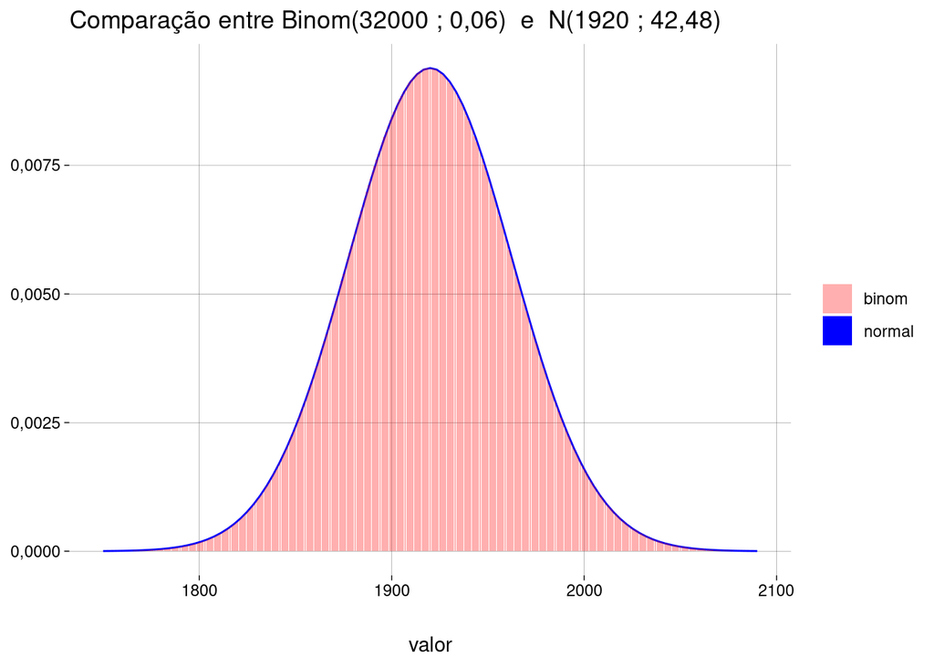

- Mas nem toda binomial se parece com uma normal:

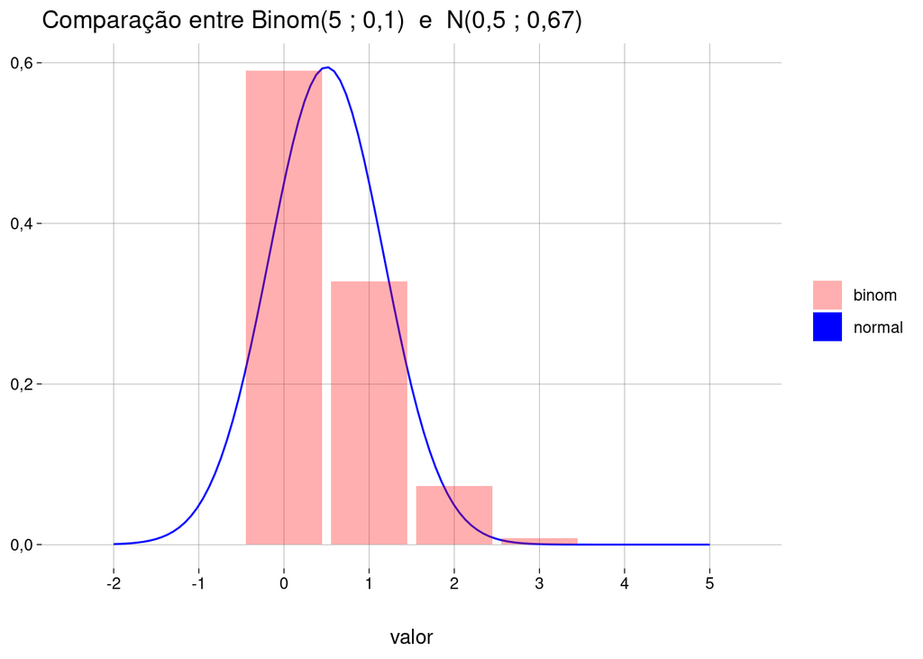

```r
n <- 5
p <- .1
normal_binom(n, p, limites = c(-2, 5)) +
  scale_x_continuous(breaks = -2:5)
```

- Neste exemplo, quanto da probabilidade da normal está em valores abaixo de $-0.5$ (valores que não fazem sentido para a binomial!)?

```r
pnorm(-.5, n * p, sqrt(n * p * (1 - p)))
```

```
## [1] 0,06801856
```

- Como resolver isto?
- Lembrando que $99{,}7\%$ da probabilidade da distribuição normal está a $3$ desvios padrão de distância da média, podemos exigir que a distribuição binomial esteja dentro destes limites.
- Então, a normal deve ser $\mathcal{N}(\mu, \sigma)$ tal que o intervalo de $\mu - 3\sigma$ até $\mu + 3\sigma$ só tenha valores positivos.
- Ou seja, queremos
  $$\mu - 3\sigma > 0$$
- O que equivale a
  $$\mu > 3\sigma$$
- Como a normal é calculada a partir de $\text{Binom}(X \mid n, p)$, isto equivale a
  $$np > 3 \sqrt{np(1-p)}$$
- Elevando os dois lados ao quadrado:
  $$n^2p^2 > 9np(1-p)$$
- Dividindo ambos os lados por $np$ (que é positivo):
  $$np > 9(1-p)$$
- Como $(1-p) \leq 1$, podemos nos satisfazer com
  $$np > 9$$
- **Conclusão:**
  - Para aproximar a binomial $\text{Binom}(X \mid n, p)$ por uma normal, exigimos que $np$ seja pelo menos $10$.
  - Como a normal é simétrica, também exigimos que $n(1-p)$ também seja pelo menos $10$.
  - Em outras palavras, o número esperado de sucessos e o número esperado de fracassos precisam ser, ambos, maiores ou iguais a $10$.

## 2.6 Correção de continuidade

- E se, no exemplo dos doadores de sangue, quiséssemos calcular a probabilidade de a organização obter *exatamente* $1.850$ doadores com sangue O-?

```r
dbinom(1850, 32000, .06)
```

```
## [1] 0,002420205
```

- Usando a aproximação normal, como calcularíamos esta probabilidade? Como a normal é uma distribuição contínua, $P(X = 1850)$ é igual a zero (como qualquer probabilidade pontual)!
- A solução é calcular $P(1849{,}5 \leq X \leq 1850{,}5)$:

```r
probs <- pnorm(
  c(1849.5, 1850.5),
  mean = 32000 * 0.06,
  sd = sqrt(32000 * 0.06 * (1 - 0.06))
)

probs[2] - probs[1]
```

```
## [1] 0,002416361
```

- Trabalhando com uma distribuição $\text{Binom}(X \mid n = 20, p = 0{,}5)$, isto fica claro no gráfico. Cada barra centrada no valor $x$ compreende uma região de $x - 0{,}5$ até $x + 0{,}5$:

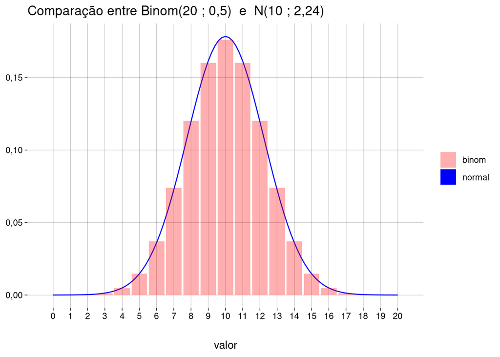

# 3 Exponencial

## 3.1 Exemplo

- Lembre-se de que a distribuição de Poisson modela o número de ocorrências de um fenômeno que tem uma média de $\lambda$ ocorrências por período de tempo.
- Imagine que o números de visitas por minuto à sua página web é $\lambda = 4$.
- Então, o *tempo* entre visitas é uma variável aleatória contínua $X$, que pode ser modelada pela distribuição exponencial com média $1/\lambda = 1/4 = 0{,}25$.
- Qual a probabilidade de que o tempo entre uma visita e a próxima seja menor do que $0{,}33$ minuto?
  $$\begin{align*}
  P(X \leq 0{,}33 \mid \lambda = 4)
  &= \int_0^{0{,}33} \lambda e^{-\lambda \cdot 0{,}33} dx \\
  &= 1 - e^{-\lambda \cdot 0{,}33} \\
  &= 1 - e^{-1{,}32} \\
  &\approx 0{,}73
  \end{align*}$$

## 3.3 Em R

- Densidade: `dexp(x, rate = 1)`
- Probabilidade acumulada: `pexp(q, rate = 1, lower.tail = TRUE)`
- Quantil: `qexp(p, rate = 1, lower.tail = TRUE)`
- Geração de números aleatórios: `rexp(n, rate = 1)`

# 4 Outras distribuições contínuas importantes

- Distribuição $t$ de Student
- Distribuição $\chi^2$
- Distribuição $F$

# 5 Jardim zoológico de distribuições

Para sua diversão: https://ben18785.shinyapps.io/distribution-zoo/